# Manuscript: Postoperative Critical Care and High-Acuity Care Provision in the United Kingdom, Australia and New Zealand

DJN Wong, S Popham, AM Wilson, LM Barneto, HA Lindsay, L Farmer, D Saunders, S Wallace, D Campbell, PS Myles, SK Harris and SR Moonesinghe, on behalf of the SNAP-2: EPICCS Collaborators

February 2019

## Abstract

### Background

Decisions to admit high-risk postoperative patients to critical care may be affected by resource availability. We aimed to quantify adult Intensive Care/High Dependency Unit (ICU/HDU) capacity in hospitals from UK, Australia and New Zealand (NZ), and to identify and describe additional “high-acuity” beds capable of managing high-risk patients outside the ICU/HDU environment.

### Methods

We used a modified Delphi consensus method to design a survey which was disseminated via investigator networks in the UK, Australia and NZ. Hospital- and ward-level data were collected, including: bed numbers; tertiary services offered; presence of an emergency department; ward staffing levels and the availability of critical care facilities.

### Conclusions

Postoperative critical care resources differ in the UK, Australia and NZ. We have, for the first time, described high-acuity beds which may have developed to augment the capacity to deliver postoperative critical care.

## Keywords

Perioperative Care; Critical Care; Health Services Research

## Introduction

Surgery is common and will become increasingly prevalent as populations grow and age.<sup>1 2</sup> Globally, the volume of surgery has been estimated at around 313 million cases a year, with high-income countries conducting procedures at a mean rate of 11,168 per 100,000 population per year.<sup>3</sup> While surgery is a treatment for disease, complications from surgery are associated with significant morbidity and mortality.<sup>4 5</sup> Critical care or protocolised pathways delivered in enhanced care areas are thought to mitigate against the risks of surgery, via the higher nurse-to-patient ratio, medical input from specialist intensivists, and availability of specific organ support therapies.<sup>6 7</sup> As the global burden of surgery increases, the numbers of patients at risk of perioperative complications rises correspondingly. Therefore, the capacity to prospectively admit high-risk patients to critical care following surgery becomes an increasing population concern.

In Australia and New Zealand (NZ), there are currently no national guidelines for risk stratifying postoperative critical care admissions. However, in the UK, the National Confidential Enquiry into Patient Outcome and Death (NCEPOD) recommends critical care admission when the preoperative estimated risk of mortality is ≥5%, while the Royal College of Surgeons of England and the Department of Health recommend that those with mortality risks ≥10% should be admitted.<sup>8 9</sup>

However, despite these guidelines, multiple observational studies report that critical care resources are not reliably allocated to patients at highest risk of death.<sup>10–12</sup> In some countries, a lack of critical care capacity is thought to contribute to this phenomenon.<sup>13</sup> Recent commentary suggests that alternative facilities are consequently being used to provide enhanced care to patients outside of the traditional Intensive Care and High Dependency Units (ICU/HDUs) in some hospitals in the UK.<sup>14</sup> These “high-acuity” beds may be able to provide a subset of the interventions and monitoring capabilities usually associated with critical care, and provide the necessary environment to manage the postoperative recovery of high-risk surgical patients.

We therefore performed a survey to assess the available postoperative facilities for high-risk patients in UK, Australian and NZ hospitals as part of the Second Sprint National Anaesthesia Project: EPIdemiology of Critical Care provision after Surgery (SNAP-2: EPICCS) study, an international observational cohort study investigating uncertainties around postoperative critical care.<sup>15</sup> The aim of this survey was to describe and compare the critical care, enhanced care and usual ward care availability for surgical patients in each of these countries, according to hospital types and health systems. We also aimed to investigate the hospital factors associated with critical care bed capacity, and with the likelihood of high-acuity bed availability at each site.

## Methods

We performed a survey in all hospital sites which expressed an interest in participating in SNAP-2: EPICCS in the UK, Australia and NZ.<sup>15</sup> In the UK, sites were identified from a list of National Health Service (NHS) hospitals which undertake adult inpatient surgery, and from the list of hospitals which participated in the First Sprint National Anaesthesia Project (SNAP-1).<sup>16–19</sup> UK Sites were then invited to participate via approaches to the lead collaborators from SNAP-1, and the Royal College of Anaesthetists’ (RCoA) network of Quality Audit and Research Coordinators (QuARCs). The QuARCs are a comprehensive network of researchers covering almost all UK NHS hospital trusts and have previously been instrumental in delivering the RCoA’s National Audit Projects.<sup>20 21</sup> In Australia, all public hospitals accredited by Australian and New Zealand College of Anaesthetists (ANZCA) to provide postgraduate anaesthesia training were invited to participate. The Australian Society of Anaesthetists (ASA) state representatives, and ANZCA Clinical Trials Network (ANZCA CTN) contacted anaesthetic departments and anaesthetic department research leads via their respective national networks. In NZ, the Supportive Anaesthesia Trainee aUdit & Research Network for NZ (SATURN) approached all public hospitals accredited by ANZCA based on NZ government Ministry of Health (MoH) listings of all public hospitals providing adult inpatient surgical services. Ethical approval was not necessary, as no patient level data were collected.

The survey was conducted between 01 December 2016 and 31 March 2017 in the UK, and between 01 December 2016 and 31 January 2018 in Australia and NZ. Lead collaborators at each site were asked to answer survey questions based on their own knowledge of their hospitals’ structures and processes, and to approach senior hospital and nursing management teams for additional support to obtain information. Where hospital trusts and organisations operated across more than one geographical site, individual responses were requested for each location.

### Questionnaire design

The survey was developed using a modified Delphi consensus method. A study steering group was convened with representatives from the RCoA, Faculty of Intensive Care Medicine (FICM), Intensive Care Society, Association of Anaesthetists of Great Britain and Ireland, Royal College of Surgeons (England), and lay representation (Supplementary Material). Draft questions were circulated among steering group members for anonymous feedback and evaluation (Round 1). The responses were collated by a facilitator at the National Institute of Academic Anaesthesia Health Services Research Centre (NIAA HSRC). The draft questions were modified based on Round 1 feedback, and these questions then used to construct a pilot questionnaire. The pilot questionnaire was re-circulated to members of the steering group, and the survey was piloted in eight participating hospitals. A second cycle of anonymous feedback was then obtained (Round 2). The final survey was then constructed based on the responses from the Round 2 (final survey questions are reported in Supplementary Material).

The survey questionnaire was designed in the UK. To facilitate international comparisons, no further changes were made to the questionnaire before it was distributed in Australia and NZ. All authors considered the terminology and definitions used in each country to be equivalent in their local contexts.

The survey was distributed electronically using online forms (FormAssembly, Veer West LLC, Bloomington, Indiana, USA) to all collaborators at sites in the UK, and electronically via e-mail to investigators at sites in Australia and NZ. To improve response rates in the UK, monthly reminders were sent to collaborators who had yet to respond, and reminder frequency was increased to weekly in the last month of the survey period. In Australia, individual ASA state representatives were given autonomy in following up on invitations to participate in the survey within their respective states, and two cycles of reminders were sent via the ANZCA CTN with a final reminder sent in January 2018. In NZ, correspondence was maintained with individual investigators at each site until data collection was completed.

The survey recorded hospital-level characteristics, including: hospital size (total number of adult inpatient beds); number of adult ICU/HDU beds; types of tertiary services delivered; the presence or absence of an emergency department; nurse:patient staffing ratios; and the presence and characteristics of high-acuity care areas, which were defined as *“any other ward areas in the hospital which receive high-risk surgical patients for enhanced perioperative care”*.

We defined surgical beds as those which would be used for any adult patient undergoing a non-obstetric inpatient procedure in an operating theatre or radiology suite.<sup>15</sup>

### Statistical analyses

Descriptive statistics for normally distributed continuous data are reported with means and standard deviations (SD), and for non-normally distributed data with medians and interquartile (IQR) ranges. For all analyses, a p-value of <0.05 was considered statistically significant. Critical care bed ratios were calculated per 100 hospital beds for each participating site, based on the number of critical care and hospital beds reported by survey respondents. These bed numbers were then aggregated by country and combined with published Organisation for Economic Co-operation and Development (OECD) indicator data on per capita hospital bed numbers to obtain critical care bed ratios per 100,000 population in each country.<sup>22</sup> Univariate analysis was performed to compare characteristics of hospitals, critical care units and high-acuity care areas between each participating country, using appropriate statistical tests for continuous and categorical variables. Hypothesising that critical care capacity would be related to tertiary services provided, we investigated the association between critical care bed provision at each site and variables thought to influence critical care bed capacity, using negative binomial regression, as appropriate for count data. The response variable of critical care beds per 100 hospital beds was regressed against the following covariates: number of hospital beds; tertiary services offered; country where the hospital was located; whether high-acuity care beds were present within the hospital; and whether the hospital had an emergency department. Relative ratios (RR) were calculated to express the relative difference in critical care bed numbers associated with a particular variable, after adjusting for hospital size and other variables in the model. We further investigated the characteristics associated with the likelihood of hospitals having high-acuity care areas using logistic regression, the binary outcome variable of whether high-acuity care areas were present or absent was regressed against the following covariates: number of hospital beds; whether tertiary services were offered; country; the critical care:hospital bed ratio; and whether the hospital had an emergency department.

### Sensitivity analysis

Due to the lower national response rate from Australian sites compared to the UK and NZ, we compared the hospital characteristics of the respondent sites with published data of hospitals offering surgical services from the Australian Institute of Health and Welfare to determine if our survey sample was biased.<sup>23</sup> Our collected data were matched by hospital name to this external openly accessible dataset which categorised hospitals by type (Supplementary Material).

Statistical analyses were performed using R version 3.5.2 (2018-12-20) (R Foundation for Statistical Computing, Vienna, Austria), with the following external packages enabled: `tidyverse`, `tableone`, `sjPlot`.<sup>24–26</sup> Negative binomial and logistic regression models were constructed using the `glm` command. Code for all analyses is available on request.

## Results

### Overview

We received responses from 309 hospitals across the UK, Australia and NZ.

In the UK, 257 hospitals responded out of the 263 invited to participate (response rate 97.72%); these hospitals were nested within 141 English NHS Trusts, 13 Scottish NHS Boards, 6 Welsh Health Boards, and 4 Northern Irish Health and Social Care Trusts. Our sample therefore represented 94.8% of NHS secondary care organisations providing adult inpatient surgical services in the UK.

In Australia, 107 hospitals were invited to participate, with 35 sites responding (response rate 32.71%). In NZ, 18 hospitals were invited to participate, with 17 sites responding (response rate 94.44%). Responding Australian hospitals were more likely to be medium to large hospitals as classified by the Australian Institute of Health and Welfare, which offer a wider range of specialist services than the general population of Australian hospitals (Sensitivity Analysis, Supplementary Material).

### Hospital characteristics

The median reported hospital size in our sample was 429 beds (IQR = 280–626, Table 1). Australian (median 398.5 beds, IQR 255.75–600 beds) and NZ (median 315 beds, IQR 193–540 beds) hospitals were not significantly different in size to those in the UK (median 450 beds, IQR 290–650 beds).

The majority of responding hospitals were acute hospitals with emergency departments on-site (n = 256, 82.85%). 178 hospitals (57.61%) provided tertiary services. However, a higher proportion of hospitals in Australia (n = 27, 77.14%) and NZ (n = 14, 82.35%) in this study were tertiary institutions than those in the UK (n = 137, 53.31%). A sensitivity analysis performed indicated our Australian data sample was weighted towards medium-to-large hospitals offering more specialist services (Supplementary Table 1).

### Critical care beds

Most hospitals reported having on-site ICU/HDU facilities (n = 283, 91.59%), with a median ratio of 2.84 (IQR 2.11–4.39) critical care beds per 100 hospital beds. 460 separate critical care units were described within 283 hospitals across all 3 countries (Table 2). 315 of these units (68.48%) admitted patients from different specialties. However, 79 hospitals (17.17%) reported having at least one specialist critical care unit, and there were 145 such specialist units identified. Among these specialist units, 43 (28.29%) would admit patients from another specialty if necessary, with the remainder restricting admissions to patients from single specialties only (e.g. cardiothoracics, or neurosurgery).

The median number of critical care beds across all units was 10 (IQR 6–15). The estimated number of critical care beds and ventilated beds per capita calculated using our sample was highest in Australia (Table 3).

UK hospitals had a smaller proportion of critical care beds per 100 hospital beds (median 2.67, IQR 2.07–4.31) compared to hospitals in Australia (median 3.74, IQR 3.02–4.93) and NZ (median 3.5, IQR 2.55–4.12). However, after adjusting for tertiary services delivered, and hospital size, the proportion of critical care beds to total hospital beds was lower in Australia (RR 0.6, 95% CI 0.49–0.75, p = 8.3610^{-6}) and NZ (RR 0.64, 95% CI 0.49–0.85, p = 0) than in the UK (Supplementary Table 3 for model coefficients). Neither the presence of an emergency department, nor the presence of enhanced ward areas were associated with the proportion of critical care beds in any of the three countries.

### High-acuity care areas

These areas were able to deliver a heterogeneous subset of interventions normally associated with critical care (Table 4), ranging from continuous observations and monitoring (n = 128, 87.07%), to Non-Invasive Ventilation (NIV) or Continuous Positive Airways Pressure (CPAP) support (n = 56, 38.1%).

Larger hospitals (adjusted odds ratio [OR] 1.97 for every standard deviation increase in hospital bed numbers, 95% CI 1.41–2.83, p = 0) providing tertiary services (adjusted OR 2.42, 95% CI 1.24–4.84, p = 0.01) were more likely to report having high-acuity care areas. Hospitals with emergency departments (adjusted OR 0.27, 95% CI 0.11–0.63, p = 0) were less likely to report having these types of beds. Full coefficients for our logistic regression model are available in Supplementary Table 4.

After critical care and high-acuity bed numbers were considered together, the total potential per capita capacity for delivering at least some critical care to postoperative patients increases in all three countries (Table 3).

### General surgical wards

Across all three countries, hospitals reported a median ratio of 28.26 surgical beds per 100 hospital beds (IQR 21.3–36). The average surgical ward was reported as having a median 26 beds (IQR 22–30 beds). The median nurse:patient ratio during the day time was 1:5.71 (IQR 1:4.5–1:7, Table 5), and this ratio dropped to a median of 1:9 nurse:patients (IQR 1:7–1:11) at night.

General surgical ward nurses in the UK were responsible for more beds per nurse than in Australia or NZ, both in the day and at night (Table 5, p <0.001). The majority of UK (n = 252, 98.05%) and NZ (n = 16, 94.12%) hospitals reported staffing surgical wards with health care assistants to supplement the care delivered by nurses. In contrast, health care assistants were less commonly employed in Australia with only 18 hospitals (51.43%) reporting their deployment on surgical wards.

## Discussion

### Principal Findings

We present a comprehensive overview of postoperative critical care facilities available for patients undergoing inpatient surgery in the UK, Australia and NZ. Our study describes the critical care provision in hospitals within these countries, and quantifies the availability of high-acuity care areas where postoperative patients may receive critical care therapies outside of the traditional ICU/HDU setting. Hospitals in NZ were generally smaller compared to the UK and Australia. The proportion of hospital beds which were dedicated to critical care was similar across the three countries, however the estimated per capita critical care capacity was highest in Australia. General surgery wards in Australia and NZ reported more favourable nurse:patient staffing ratios than the UK. High-acuity care areas delivering some critical care interventions were present in all three countries, and these were of similar size and nurse staffing ratios. The total potential per capita capacity for delivering at least some critical care to postoperative patients increases after these enhance care areas are taken into account.

### Strengths and weaknesses

Our survey had nearly complete coverage of all UK and NZ public secondary care organisations that provide inpatient surgical care. The data collected is therefore likely to be an accurate representation of available postoperative facilities in both countries.

While NHS England collects data on critical care bed numbers, these are aggregated at Trust level, and not individual hospital site-level. The Scottish Intensive Care Society Audit Group (SICSAG) publishes an annual audit report of critical care outcomes and facilities, against which we cross-checked our results, and found high levels of agreement.<sup>27</sup> To our knowledge the national health authorities in Wales and Northern Ireland do not compile publicly accessible data of this nature for secondary analysis. The Australian New Zealand Intensive Care Society (ANZICS) publishes an annual report with information on the total number of adult intensive care units across Australia and NZ, which includes numbers of paediatric intensive care beds in their counts.<sup>28</sup> Our data are therefore comprehensive and robust, and contain information not routinely collected by national bodies in all three countries. A further key strength of this study is that we have been able to provide the first empirical description of perioperative high-acuity care areas.

There are however also some weaknesses to this work. First, the response rate in Australia was lower than in the UK and NZ. A *post hoc* sensitivity analysis conducted showed that the Australian hospitals sampled in our study was weighted towards medium-to-large major hospitals which provide postgraduate anaesthesia specialty training, and capable of delivering higher numbers of specialist services (Supplementary Material). Second, a higher proportion of NZ hospitals that responded were tertiary institutions. Larger tertiary institutions in Australia and NZ may have had increased motivation to participate in our study, and survey dissemination via local networks may have favoured tertiary hospitals due to the nature of the networks used (the anaesthesia trainee research networks relied upon to distribute the survey are more likely to be found within larger tertiary hospitals). Third, private sector hospitals were also not approached in our survey, and we therefore were not able to explore the pathways in those institutions, which we acknowledge may provide a substantial proportion of elective surgical care, especially in Australia, where the spend on private healthcare as a proportion of total healthcare expenditure is higher compared to UK and NZ (UK: 21.9%, Australia: 31.9%, and NZ: 21.1% of healthcare spend).<sup>29</sup> These differences in our sample must be considered when considering the comparative data we present about the three countries. Finally, due to the difference in population distributions in Australia and NZ, these nations have a large number of geographically dispersed small rural hospitals, usually without critical care provision, and linked to central hubs of secondary/tertiary care; these differences from the UK make direct comparisons of health systems difficult.

### Defining critical care

Historically, critical care bed capacity per capita in the UK, Australia and NZ has been found to be low compared to many other developed health systems.<sup>13 30</sup> However, research in this area is made difficult by the lack of international consensus in critical care definitions. In the UK, Guidelines for the Provision of Intensive Care Services (GPICS) were recently published by the Faculty of Intensive Care Medicine and Intensive Care Society in 2015,<sup>31</sup> following on from earlier publications which aimed to describe ICU/HDU standards in the UK.<sup>32 33</sup> In Australia and NZ, the College of Intensive Care Medicine (CICM) defines minimum standards for ICU and HDU in separate documents.<sup>34 35</sup>

A Level 0-3 classification system has been adopted in the UK, and it is referred to extensively in GPICS. Level 3 indicates care for complex patients requiring support for multi-organ failure and with a minimum of 1:1 nurse:patient ratio, while Level 2 indicates care for patients with single organ support and a minimum 1:2 nurse:patient ratio. In contrast to the UK, Level I, II and III ICU definitions in Australia and NZ, refer not to patient dependency but instead to multiple organisational factors relating to work practice/caseload, staffing requirements, operational requirements, design, and monitoring and equipment standards.<sup>34</sup> In Australia and NZ, Level III ICUs are tertiary referral units for intensive care patients, while Level I and II ICUs are rural units serving smaller popoulations where there are limited specialist services available, and where travel to specialist services may cause delay.<sup>34</sup> Therefore Level I-III ICUs in Australia and NZ are all able to provide a period of mechanical ventilation, and HDUs do not come under this classification system.<sup>35</sup>

### Other less clearly defined “high-acuity care” areas - Level 1.5 units?

Beyond the definitions above, there are other patient care areas within the hospital, which do not traditionally fall under the widely accepted umbrella of ICU/HDU critical care units. These other areas have the ability to care for patients who require one or more interventions associated with critical care. For example, within the Emergency Department, resuscitation bays have the facilities to temporarily care for critically ill patients requiring intensive nursing/medical interventions. Another example would be the cardiologists’ Coronary Care Unit, which may have the ability to deliver 1:1 or 1:2 nursing, invasive blood pressure monitoring, continuous ECG telemetry and inotropic/vasopressor support.

We sought to identify high-acuity care areas capable of delivering higher levels of postoperative care compared to usual ward level care. We suggest that these high-acuity beds have evolved in the UK, Australia and NZ to compensate for the low critical care capacity for high-risk patients. These areas may be thought of as “Level 1.5” units, to borrow from the traditional UK classification system described above. Our survey has demonstrated that many hospitals may use such facilities to deliver postoperative critical care to patients.

### Our results in relation to existing literature

Using administrative panel data from multiple different sources, Adhikari *et al* estimated the per capita ratio of critical care beds in a number of countries, and further estimated the number of ICU beds per 100 hospital beds.<sup>13</sup> They reported 1.2 ICU beds per 100 hospital beds for the UK, and 1.5 ICU beds per 100 hospital beds for NZ public hospitals, but did not provide estimates for Australia. They also further estimated per capita ICU bed ratios of 3.5, 5.6 and 4.7 per 100,000 population for UK, Australia and NZ respectively. In a separate study of European critical care capacity, Rhodes *et al* estimated 2.8 ICU beds per 100 hospital beds and 6.6 ICU/intermediate care beds per 100,000 population for the UK in 2012.<sup>30</sup>

The ANZICS Centre for Outcome and Resource Evaluation reported 9.0 ICU beds per 100,000 population in Australia and 5.3 ICU beds per 100,000 population in NZ.<sup>28</sup> These numbers are similar to our estimates for ventilated critical care beds per 100,000 population for each country.

Using intermediate definitions for surgery, approximately 8,000 surgical procedures were performed per 100,000 population per year in the UK NHS between 2009 and 2014, with an estimated 3,810 per 100,000 per year requiring overnight stay.<sup>39</sup> In comparison, 4,584 an estimated surgical admissions per 100,000 population per year occur in Australian public hospitals,<sup>40</sup> and 4,669 surgical procedures per 100,000 population per year are performed in New Zealand.<sup>1 3</sup> Therefore, combining the results from our study with the other data obtained from the literature, the availability of critical care beds in relation to volume of surgical activity performed in public hospitals can be approximated for each country (UK = 2.45, Australia = 3.06, New Zealand = 1.96 critical care beds per 1,000 surgical procedures). However, these estimates are may be limited by differences in the definitions used when accounting for surgical volume between the different statistical sources.

### Unanswered questions and future research

What is clear from our study is the prevalence of high-acuity beds in many of hospitals throughout the three countries studied. We propose that these high-acuity beds are being used to augment the critical care capacity in hospitals where ICU/HDU beds may be insufficient to support clinical activity. However, we are unable to comment on patient case-mix within these areas, or on the clinical effectiveness of treatment in these units. The high-acuity care areas likely represent a heterogenous group of bed types and further research is required to describe the detail of the structures and processes within these units, and the outcomes of patients admitted to them. We do not currently know if they provide good value care and whether they are a sufficient alternative to traditional ICU/HDU care for high risk patients. Rapid expansion in their numbers cannot currently be recommended without further evaluation.

Other important factors which might influence the capacity to deliver postoperative care to high-risk patients may also need further exploration. Particularly, the effects of hospital networking arrangements across large geographical regions was not explored in our study. Inter-hospital transfer is an established mechanism for diverting patients when critical care capacity may be inadequate in the transferring hospital, or when centralised tertiary services only available in the receiving hospital are required.<sup>41</sup> There is evidence that patients transferred for non-clinical indications may have longer lengths of stay, but equivalent mortality outcomes, and therefore critical care capacities across regions may be important in resource planning beyond the immediate needs of a single hospital.<sup>42</sup>

### Conclusion

There are differences between the UK, Australia and NZ in postoperative provision of care, both in terms of critical care capacity, and also staffing levels in general surgical wards. There are no significant differences in critical care bed numbers as a proportion of total beds at each hospital between the three countries, after adjusting for hospital size and tertiary care provision. We identify and describe high-acuity care areas which accommodate high-risk surgical patients for postoperative management. Per capita postoperative critical care availability was lowest in the UK after accounting for these high-acuity care beds. We suggest that high-acuity care areas may have developed organically to facilitate the provision of some aspects of critical care — in particular more favourable nurse:patient ratios — outside the ICU and HDU, in order to meet service demand. However, the utility of these high-acuity beds requires further evaluation.

## Details of authors contributions

The study was conceived by SRM Study data collection was coordinated by DJNW in the UK, SP, PSM and SW in Australia, and AMW, LMB, HAL and DC in New Zealand. Study data were prospectively collected by lead collaborators at each participating hospital site. Data linkage and cleaning was performed by DJNW. Analysis was performed by DJNW, with input to analysis from SKH and SRM. The manuscript was drafted by DJNW and subsequently revised after critical review by all authors.

## Acknowledgements

We thank all SNAP-2: EPICCS site investigators and collaborators for contributing data to this study. We thank the SNAP-2: EPICCS Study Steering Group for contributing to study questionnaire construction. We also thank Dr David Highton for providing comments and suggestions to the manuscript. Details of all collaborators and Steering Group members can be found in the appendix.

## Declaration of interests

SRM is Director of the NIAA Health Services Research Centre and the UCLH Surgical Outcomes Research Centre and Associate National Clinical Director for elective care at NHS England. PSM is an editor for the British Journal of Anaesthesia. SP was the Chair of the Trainee Members Group of the Australian Society of Anaesthetists at the time of study data collection. AMW, LMB, HAL, LF, DS and DC report no conflicts of interest.

## Funding

SNAP-2: EPICCS has been supported by the National Institute for Academic Anaesthesia (Association of Anaesthetists of Great Britain and Ireland Project grant), the Royal College of Anaesthetists and the UCLH NIHR Biomedical Research Centre in the UK. The study is adopted in the UK onto the NIHR Clinical Research Portfolio and equivalents in the devolved nations, and supported by NIHR Local Clinical Research Networks. SRM and SKH are Improvement Science Fellows funded by the Health Foundation. SRM is supported for her role as Director of the NIAA Health Services Research Centre by funding from the Royal College of Anaesthetists. DJNW received salary support from The London Clinic hospital and the UCLH NIHR Surgical Outcomes Research Centre.

## Tables

### Table 1

Table 1: Summary of hospital characteristics.

|  | Overall | UK | Aus | NZ | p | test |
| --- | --- | --- | --- | --- | --- | --- |
| **n** | 309 | 257 | 35 | 17 |  |  |
| **Total hospital beds (median [IQR])** | 429.00 [280.00, 626.00] | 450.00 [290.00, 650.00] | 398.50 [255.75, 600.00] | 315.00 [193.00, 540.00] | 0.095 | nonnorm |
| **Emergency department present = TRUE (%)** | 256 (82.8) | 207 (80.5) | 33 (94.3) | 16 (94.1) | 0.058 |  |
| **Total critical care beds (median [IQR])** | 12.00 [8.00, 22.00] | 12.00 [8.00, 21.00] | 14.00 [8.00, 26.00] | 9.00 [6.00, 16.00] | 0.435 | nonnorm |
| **Total ventilated beds (median [IQR])** | 8.00 [6.00, 14.25] | 8.00 [6.00, 13.00] | 10.50 [5.00, 20.00] | 5.50 [3.75, 11.50] | 0.124 | nonnorm |
| **Proportion of critical care beds per 100 hospital beds (median [IQR])** | 2.84 [2.11, 4.39] | 2.67 [2.07, 4.31] | 3.74 [3.02, 4.93] | 3.50 [2.55, 4.12] | 0.014 | nonnorm |
| **Total general surgical ward beds (median [IQR])** | 120.00 [64.00, 189.00] | 121.00 [70.00, 189.25] | 90.00 [48.00, 156.00] | 86.50 [47.50, 194.75] | 0.309 | nonnorm |
| **Post-Anaesthesia Care Unit (PACU) present = TRUE (%)** | 7 (2.3) | 6 (2.3) | 1 (2.9) | 0 (0.0) | 0.797 |  |
| **High-acuity care area present = TRUE (%)** | 92 (29.8) | 72 (28.0) | 14 (40.0) | 6 (35.3) | 0.304 |  |
| **tertiaryServices = TRUE (%)** | 178 (57.6) | 137 (53.3) | 27 (77.1) | 14 (82.4) | 0.003 |  |

### Table 2

Table 2: Summary of critical care unit characteristics.

|  | Overall | UK | Aus | NZ | p | test |
| --- | --- | --- | --- | --- | --- | --- |
| **n** | 460 | 397 | 40 | 23 |  |  |
| **Total critical care beds (median [IQR])** | 10.00 [6.00, 15.00] | 10.00 [7.00, 15.00] | 10.00 [6.75, 18.00] | 8.00 [6.00, 10.00] | 0.199 | nonnorm |
| **Total ventilated beds (median [IQR])** | 6.00 [0.00, 10.00] | 7.00 [0.00, 10.00] | 7.00 [4.00, 15.00] | 5.00 [2.50, 8.00] | 0.098 | nonnorm |
| **ICU/HDU/Mixed (%)** |  |  |  |  | 0.206 |  |
| **HDU** | 136 (29.6) | 125 (31.6) | 6 (15.0) | 5 (21.7) |  |  |
| **ICU** | 73 (15.9) | 61 (15.4) | 7 (17.5) | 5 (21.7) |  |  |
| **Mixed** | 250 (54.5) | 210 (53.0) | 27 (67.5) | 13 (56.5) |  |  |
| **Specialty unit (%)** |  |  |  |  | 0.304 |  |
| **Cardiothoracic** | 41 (8.9) | 35 (8.8) | 4 (10.0) | 2 (9.1) |  |  |
| **General/Mixed** | 315 (68.6) | 263 (66.2) | 33 (82.5) | 19 (86.4) |  |  |
| **Medical** | 27 (5.9) | 27 (6.8) | 0 (0.0) | 0 (0.0) |  |  |
| **Neurology/Neurosurgical** | 19 (4.1) | 18 (4.5) | 1 (2.5) | 0 (0.0) |  |  |
| **Other (please elaborate)** | 27 (5.9) | 26 (6.5) | 1 (2.5) | 0 (0.0) |  |  |
| **Surgical** | 30 (6.5) | 28 (7.1) | 1 (2.5) | 1 (4.5) |  |  |
| **Will admit off-specialty patients = TRUE (%)** | 43 (28.3) | 41 (30.6) | 1 (6.7) | 1 (33.3) | 0.146 |  |

### Table 3

Table 3: Critical care and high-acuity care beds per capita. The sum of the number of critical care beds was divided by the sum of all hospital beds within each country, and multiplied by 100, to obtain the average ratio of critical care beds to hospital beds in each country. This ratio was then multiplied by OECD data on hospital beds per capita to obtain the per capita critical care bed numbers, rescaled to per 100,000 population.

| Country | Critical care beds per 100 hospital beds | Ventilated beds per 100 hospital beds | High-acuity care beds per 100 hospital beds | Critical care beds per 100,000 population | Ventilated beds per 100,000 population | High-acuity care beds per 100,000 population |
| --- | --- | --- | --- | --- | --- | --- |
| UK | 3.59 | 2.168 | 0.474 | 9.334 | 5.637 | 1.232 |
| Aus | 3.696 | 2.774 | 0.9911 | 14.05 | 10.54 | 3.766 |
| NZ | 3.386 | 2.197 | 2.362 | 9.141 | 5.931 | 6.377 |

### Table 4

Table 4: Summary of high-acuity care area characteristics

|  | Overall | UK | Aus | NZ | p | test |
| --- | --- | --- | --- | --- | --- | --- |
| **n** | 147 | 109 | 21 | 17 |  |  |
| **Total beds (median [IQR])** | 4.00 [3.00, 8.00] | 4.00 [3.00, 7.00] | 4.00 [4.00, 8.00] | 5.00 [4.00, 10.00] | 0.133 | nonnorm |
| **Patient:Nurse ratio (median [IQR])** | 2.00 [2.00, 4.00] | 2.00 [2.00, 4.00] | 2.00 [2.00, 4.00] | 2.00 [2.00, 3.00] | 0.983 | nonnorm |
| **enhancedWardConsult (%)** |  |  |  |  | 0.457 |  |
| **Intensivist** | 7 (4.8) | 7 (6.4) | 0 (0.0) | 0 (0.0) |  |  |
| **Multi-specialty Joint Care** | 34 (23.1) | 28 (25.7) | 3 (14.3) | 3 (17.6) |  |  |
| **Other (please elaborate)** | 18 (12.2) | 11 (10.1) | 4 (19.0) | 3 (17.6) |  |  |
| **Perioperative Anaesthetist** | 15 (10.2) | 13 (11.9) | 1 (4.8) | 1 (5.9) |  |  |
| **Surgeon** | 73 (49.7) | 50 (45.9) | 13 (61.9) | 10 (58.8) |  |  |
| **Able to provide continuous observations/monitoring = TRUE (%)** | 128 (87.1) | 94 (86.2) | 19 (90.5) | 15 (88.2) | 0.859 |  |
| **Able to provide invasive blood pressure monitoring = TRUE (%)** | 83 (56.5) | 66 (60.6) | 10 (47.6) | 7 (41.2) | 0.220 |  |
| **Able to manage vasoactive infusions = TRUE (%)** | 64 (43.5) | 46 (42.2) | 9 (42.9) | 9 (52.9) | 0.707 |  |
| **Able to provide invasive ventilation = TRUE (%)** | 6 (4.1) | 6 (5.5) | 0 (0.0) | 0 (0.0) | 0.336 |  |
| **Able to provide non-invasive ventilation/continuous positive airway pressure (NIV/CPAP) = TRUE (%)** | 56 (38.1) | 37 (33.9) | 12 (57.1) | 7 (41.2) | 0.129 |  |
| **Able to manage epidural catheters = TRUE (%)** | 101 (68.7) | 74 (67.9) | 19 (90.5) | 8 (47.1) | 0.015 |  |

### Table 5

Table 5: Summary of general ward staffing levels

|  | Overall | UK | Aus | NZ | p | test |
| --- | --- | --- | --- | --- | --- | --- |
| **n** | 309 | 257 | 35 | 17 |  |  |
| **Number of beds (median [IQR])** | 26.00 [22.00, 30.00] | 25.00 [22.00, 30.00] | 30.00 [24.00, 32.00] | 27.50 [25.00, 30.00] | 0.008 | nonnorm |
| **Number of nurses (day) (median [IQR])** | 4.00 [4.00, 6.00] | 4.00 [3.00, 5.00] | 8.00 [7.00, 9.00] | 6.00 [5.00, 8.00] | <0.001 | nonnorm |
| **Beds:Nurse ratio (day) (median [IQR])** | 5.71 [4.50, 7.00] | 6.00 [5.00, 7.50] | 3.75 [3.43, 4.00] | 4.45 [3.62, 5.00] | <0.001 | nonnorm |
| **Number of nurses (night) (median [IQR])** | 3.00 [2.00, 4.00] | 3.00 [2.00, 3.00] | 4.00 [4.00, 4.50] | 3.00 [3.00, 3.62] | <0.001 | nonnorm |
| **Beds:Nurse ratio (night) (median [IQR])** | 9.00 [7.00, 11.00] | 9.33 [7.33, 11.83] | 6.86 [6.00, 8.00] | 8.67 [7.22, 9.33] | <0.001 | nonnorm |
| **Health Care Assistants utilised = TRUE (%)** | 286 (92.6) | 252 (98.1) | 18 (51.4) | 16 (94.1) | <0.001 |  |

## Figures

### Figure 1

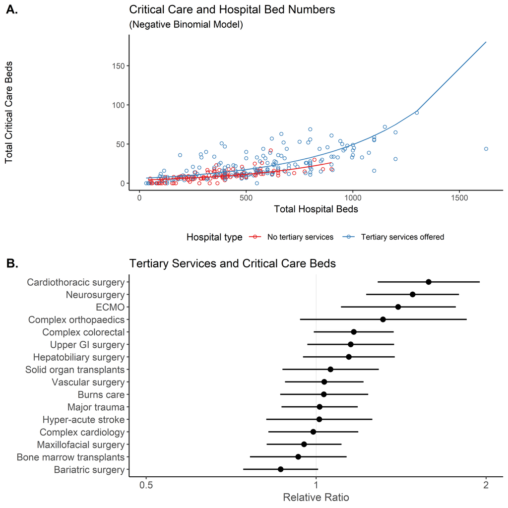

Figure 1A: Scatter plot of critical care beds vs. hospital size, with hospitals coloured by tertiary status. Lines of best fit as estimated using a negative binomial regression model illustrate the higher number of critical care beds in hospitals offering tertiary services, compared to hospitals not offering tertiary services.; Figure 1B: Forest plot of associations between specialist services delivered and the relative availability of critical care beds per 100 hospital beds, after adjusting for hospital size, presence of enhance ward areas, presence of emergency department and country.

## Supplementary Material

### Collaborator and Steering Group List

Thank you to the collaborators who contributed data to this study. All collaborators are listed with their hospital affiliations in parentheses.

#### Study Steering Group

Mike P. W. Grocott, Robert Sneyd, Anna Batchelor, Stephen Brett, Catherine Plowright, Suman Shrestha, Richard Shawyer, Shafi Ahmed, Mizan Khondoker, Mike Nathanson

#### United Kingdom

Sonia Sathe (*Abertawe Bro Morgannwg University Health Board - Princess of Wales Hospital*), Shilpa Rawat (*Abertawe Bro Morgannwg University Health Board - Singleton Hospital*), Christine Range (*Abertawe Bro Morgannwg University Health Board - Morriston Hospital*), Dermot Moloney (*Aintree University Hospital NHS Foundation Trust - Aintree University Hospital*), Wendy Lum Hee (*Airedale NHS Foundation Trust - Airedale General Hospital*), James Tozer (*Aneurin Bevan Health Board - Royal Gwent Hospital*), Vincent Hamlyn (*Aneurin Bevan Health Board - Nevill Hall Hospital*), Mark MacGregor (*Ashford and St Peter’s Hospitals NHS Foundation Trust - Ashford Hospital and St Peter’s Hospital*), Shabir Qadri (*Barking, Havering and Redbridge University Hospitals NHS Trust - King George Hospital and Queen’s Hospital*), Sunil kumar Chaurasia (*Barnsley Hospital NHS Foundation Trust - Barnsley Hospital*), Hew Torrance (*Barts Health NHS Trust - Newham General Hospital*), Ashok Raj (*Barts Health NHS Trust - Whipps Cross University Hospital*), Davina Ross-Anderson (*Barts Health NHS Trust - The Royal London Hospital*), Sibtain Anwar (*Barts Health NHS Trust - St Bartholomew’s Hospital*), Samuel Armanious (*Basildon and Thurrock University Hospitals NHS Foundation Trust - Basildon University Hospital*), Peter Knowlden (*Bedford Hospital NHS Trust - Bedford Hospital South Wing*), Killian McCourt (*Belfast Health and Social Care Trust - Royal Victoria Hospital*), Richard Pugh (*Betsi Cadwaladr University Health Board - Glan Clwyd Hospital*), Stephan Clements (*Betsi Cadwaladr University Health Board - Ysbyty Gwynedd*), Christopher Littler (*Betsi Cadwaladr University Health Board - Wrexham Maelor Hospital*), Annabelle Whapples (*Birmingham Women’s NHS Foundation Trust - Birmingham Women’s NHS Foundation Trust*), Jason Cupitt (*Blackpool Teaching Hospitals NHS Foundation Trust - Blackpool Victoria Hospital*), Madhushankar Balasubramaniam (*Bolton NHS Foundation Trust - Royal Bolton Hospital*), Robert Spencer (*Bradford Teaching Hospitals NHS Foundation Trust - Bradford Royal Infirmary*), Stuart White (*Brighton and Sussex University Hospitals NHS Trust - Sussex Orthopaedic Treatment Centre, Princess Royal Haywards Heath and Royal Sussex County Hospital*), Jeremy Drake (*Buckinghamshire Healthcare NHS Trust - Wycombe Hospital and Stoke Mandeville Hospital*), Tendai Ramhewa (*Burton Hospitals NHS Foundation Trust - Queen’s Hospital*), Stephen Hill (*Calderdale and Huddersfield NHS Foundation Trust - Calderdale Royal Hospital and Huddersfield Royal Infirmary*), Vishal Patil (*Cambridge University Hospitals NHS Foundation Trust - Addenbrooke’s Hospital*), Naomi Goodwin (*Cardiff & Vale University Health Board - University Hospital of Wales*), Sujesh Bansal (*Central Manchester University Hospitals NHS Foundation Trust - Saint Mary’s Hospital*), Nick Greenwood (*Central Manchester University Hospitals NHS Foundation Trust - Trafford General Hospital*), Rebecca Sutton (*Central Manchester University Hospitals NHS Foundation Trust - Royal Manchester Children’s Hospital*), James Hanison (*Central Manchester University Hospitals NHS Foundation Trust - Manchester Royal Infirmary*), Melinda Same (*Chelsea and Westminster Hospital NHS Foundation Trust - Chelsea and Westminster Hospital*), Alexandra Matson (*Chelsea and Westminster Hospital NHS Foundation Trust - West Middlesex University Hospital*), Nick Spittle (*Chesterfield Royal Hospital NHS Foundation Trust - Chesterfield Royal Hospital*), Marc Slorach (*City Hospitals Sunderland NHS Foundation Trust - Sunderland Royal Hospital*), Liam McLoughlin (*Colchester Hospital University NHS Foundation Trust - Colchester General Hospital*), Lawrence Wilson (*Countess of Chester Hospital NHS Foundation Trust - Countess of Chester Hospital*), Helen Melsom (*County Durham and Darlington NHS Foundation Trust - University Hospital of North Durham*), M. Amir Rafi (*County Durham and Darlington NHS Foundation Trust - Darlington Memorial Hospital*), James Limb (*County Durham and Darlington NHS Foundation Trust - Bishop Auckland Hospital*), Ravishankar Jakkala Saibaba (*Croydon Health Services NHS Trust - Croydon University Hospital*), Ceri Lynch (*Cwm Taf Health Board - Royal Glamorgan Hospital*), Omar Pemberton (*Cwm Taf Health Board - Prince Charles Hospital*), Mansoor Sange (*Dartford and Gravesham NHS Trust - Darent Valley Hospital*), David Rogerson (*Derby Teaching Hospitals NHS Foundation Trust - Royal Derby Hospital*), Richard Dobson (*Doncaster and Bassetlaw Hospitals NHS Foundation Trust - Doncaster Royal Infirmary*), Jonathan Chambers (*Dorset County Hospital NHS Foundation Trust - Dorset County Hospital*), Jon Bramall (*East and North Hertfordshire NHS Trust - Lister Hospital*), Andrew Gorman (*East Cheshire NHS Trust - Macclesfield District General Hospital*), Moore Joanna (*East Kent Hospitals University NHS Foundation Trust - William Harvey Hospital (*Ashford*)*), Ritoo Kapoor (*East Kent Hospitals University NHS Foundation Trust - Kent and Canterbury Hospital*), Nagendra Natarajan (*East Kent Hospitals University NHS Foundation Trust - Queen Elizabeth The Queen Mother Hospital*), Srikanth Chukkambotla (*East Lancashire Hospitals NHS Trust - Burnley General Hospital and Royal Blackburn Hospital*), Philippa Marshall (*East Sussex Healthcare NHS Trust - Eastbourne District General Hospital and Conquest Hospital*), Geoff Thorning (*Epsom and St Helier University Hospitals NHS Trust - St Helier Hospital and Epsom Hospital*), Peter Csabi (*Frimley Health NHS Foundation Trust - Wexham Park Hospital*), Justin Woods (*Frimley Health NHS Foundation Trust - Frimley Park Hospital*), Jenny Ritzema (*Gateshead Health NHS Foundation Trust - Queen Elizabeth Hospital*), Robert Orme (*Gloucestershire Hospitals NHS Foundation Trust - Cheltenham General Hospital*), Sock Huang Koh (*Gloucestershire Hospitals NHS Foundation Trust - Gloucestershire Royal Hospital*), Baigel Gary (*Great Western Hospitals NHS Foundation Trust - The Great Western Hospital*), Liana Zucco (*Guy’s and St Thomas’ NHS Foundation Trust - St Thomas’ Hospital and Guy’s Hospital*), Helen Bromhead (*Hampshire Hospitals NHS Foundation Trust - Royal Hampshire County Hospital*), Richard Partridge (*Hampshire Hospitals NHS Foundation Trust - Basingstoke and North Hampshire Hospital*), Abhinav Kant (*Harrogate and District NHS Foundation Trust - Harrogate District Hospital*), Joyce Yeung (*Heart of England NHS Foundation Trust - Solihull Hospital, Heartlands Hospital and Good Hope Hospital*), Dancho Ignatov (*Hinchingbrooke Health Care NHS Trust - Hinchingbrooke Hospital*), Chiraag Talati (*Homerton University Hospital NHS Foundation Trust - Homerton University Hospital Foundation Trust*), Andrew Gratrix (*Hull and East Yorkshire Hospitals NHS Trust - Hull Royal Infirmary*), Subhamay Ghosh (*Hywel Dda Health Board - Prince Phillip Hospital*), Zhana Ignatova (*Hywel Dda Health Board - Bronglais General Hospital*), Stuart Gill (*Hywel Dda Health Board - West Wales General Hospital*), Sunita Agarwal (*Hywel Dda Health Board - Withybush General Hospital*), Vidhya Nagaratnam (*Imperial College Healthcare NHS Trust - Charing Cross Hospital and St Mary’s Hospital*), Susan Kirby (*Imperial College Healthcare NHS Trust - Queen Charlotte’s Hospital*), Stephen Brett (*Imperial College Healthcare NHS Trust - Hammersmith Hospital*), Stephanie Bell (*Ipswich Hospital NHS Trust - Ipswich Hospital*), Gabor Debreceni (*Isle of Wight NHS Trust - St Mary’s Hospital*), Pieter Bothma (*James Paget University Hospitals NHS Foundation Trust - James Paget University Hospital*), Satyanarayana Jakkampudi (*Kettering General Hospital NHS Foundation Trust - Kettering General Hospital*), Claire Botfield (*King’s College Hospital NHS Foundation Trust - Orpington Hospital*), Waisun Kok (*King’s College Hospital NHS Foundation Trust - Princess Royal University Hospital*), Ritesh Maharaj (*King’s College Hospital NHS Foundation Trust - King’s College Hospital*), Sarang Puranik (*Kingston Hospital NHS Foundation Trust - Kingston Hospital*), Shondipon Laha (*Lancashire Teaching Hospitals NHS Foundation Trust - Royal Preston Hospital*), Simon Whiteley (*Leeds Teaching Hospitals NHS Trust - Leeds General Infirmary and St James’s Hospital*), Buzz Shephard (*Lewisham and Greenwich NHS Trust - Queen Elizabeth Hospital*), Manju Agarwal (*Lewisham and Greenwich NHS Trust - University Hospital Lewisham*), Helen McNamara (*Liverpool Women’s NHS Foundation Trust - Liverpool Women’s NHS Foundation Trust*), Thomas Fitzgerald (*London North West Healthcare NHS Trust - Central Middlesex Hospital, St Mark’s Hospital and Northwick Park Hospital*), Suhail Zaidi (*Luton and Dunstable University Hospital NHS Foundation Trust - Luton and Dunstable Hospital*), Philip Blackie (*Maidstone and Tunbridge Wells NHS Trust - Tunbridge Wells Hospital at Pembury and Maidstone Hospital*), Kirtida Mukherjee (*Medway NHS Foundation Trust - Medway Maritime Hospital*), Nicolas Price (*Mid Cheshire Hospitals NHS Foundation Trust - Leighton Hospital*), James Pennington (*Mid Essex Hospital Services NHS Trust - Broomfield Hospital*), Sandeep Varma (*Mid Yorkshire Hospitals NHS Trust - Pinderfields Hospital*), Richard Stewart (*Milton Keynes University Hospital NHS Foundation Trust - Milton Keynes Hospital*), Peter O’Brien (*NHS Ayrshire & Arran - University Hospital Crosshouse*), Joellene Mitchell (*NHS Ayrshire & Arran - University Hospital Ayr*), Jonathan Aldridge (*NHS Borders - Borders General Hospital*), Vivien Edwards (*NHS Dumfries & Galloway - Dumfries & Galloway Royal Infirmary*), Catherine Hunter (*NHS Fife - Victoria Hospital*), Laurin Allen (*NHS Grampian - Aberdeen Royal Infirmary*), Jennifer Service (*NHS Greater Glasgow & Clyde - Glasgow Royal Infirmary*), Tom Pettigrew (*NHS Greater Glasgow & Clyde - New Victoria Hospital*), Robert Campbell (*NHS Greater Glasgow & Clyde - Inverclyde Royal Hospital*), Daphne Varveris (*NHS Greater Glasgow & Clyde - Queen Elizabeth University Hospital*), Simon Young (*NHS Greater Glasgow & Clyde - Institute of Neurological Sciences*), Johann Harten (*NHS Greater Glasgow & Clyde - Gartnavel General Hospital (*Admin Purposes*)*), Michael Brett (*NHS Greater Glasgow & Clyde - Royal Alexandra Hospital*), Jacqueline Howes (*NHS Highland - Raigmore Hospital*), David Robinson (*NHS Highland - Lorn & Islands Hospital*), Roddy Chapman (*NHS Lanarkshire - Monklands District General Hospital*), Austin Rattray (*NHS Lanarkshire - Hairmyres Hospital*), Khaled Razouk (*NHS Lanarkshire - Wishaw General Hospital*), Stuart McLellan (*NHS Lothian - Western General Hospital*), Robin Alston (*NHS Lothian - Royal Infirmary of Edinburgh at Little France*), Murray Geddes (*NHS Lothian - St John’s Hospital*), Stefan Schraag (*NHS National - Golden Jubilee National Hospital*), Paul Cooper (*NHS Orkney - Balfour Hospital*), Catriona Barr (*NHS Shetland - Gilbert Bain Hospital*), Stephanie Sim (*NHS Tayside - Perth Royal Infirmary*), Sharon Hilton-Christie (*NHS Tayside - Ninewells Hospital*), Caroline Reavley (*Norfolk and Norwich University Hospitals NHS Foundation Trust - Norfolk and Norwich University Hospital*), Kathryn Jenkins (*North Bristol NHS Trust - Southmead Hospital*), Tim Smith (*North Cumbria University Hospitals NHS Trust - Cumberland Infirmary*), Fiona Graham (*North Cumbria University Hospitals NHS Trust - West Cumberland Hospital*), J. A. Ezihe-Ejiofor (*North Middlesex University Hospital NHS Trust - North Middlesex University Hospital NHS Trust* ), David Pritchard (*North Tees and Hartlepool NHS Foundation Trust - University Hospital Of Hartlepool*), Lynne Williams (*North Tees and Hartlepool NHS Foundation Trust - University Hospital Of North Tees*), Prashant Kakodkar (*Northampton General Hospital NHS Trust - Northampton General Hospital [Acute]*), Garry Henry (*Northern Devon Healthcare NHS Trust - North Devon District Hospital*), Christopher Nutt (*Northern Health and Social Care Trust - Antrim Area Hospital*), Geoff Wright (*Northern Health and Social Care Trust - Causeway Hospital*), Atideb Mitra (*Northern Lincolnshire and Goole NHS Foundation Trust - Princess Of Wales Hospital*), Sanjeev Garg (*Northern Lincolnshire and Goole NHS Foundation Trust - Scunthorpe General Hospital*), Adrian Taylor (*Northumbria Healthcare NHS Foundation Trust - Northumbria Specialist Emergency Care Hospital, Hexham General Hospital, Wansbeck General Hospital and North Tyneside General Hospital*), Iain Moppett (*Nottingham University Hospitals NHS Trust - City Campus and Queen’s Medical Centre Campus*), Sam Clark (*Oxford University Hospitals NHS Foundation Trust - Nuffield Orthopaedic Centre and Churchill Hospital*), Eleanor Ford (*Oxford University Hospitals NHS Foundation Trust - Horton General Hospital*), Giles Bond-Smith (*Oxford University Hospitals NHS Foundation Trust - John Radcliffe Hospital*), Richard Siviter (*Oxford University Hospitals NHS Foundation Trust - John Radcliffe Hospital*), Stephen Webb (*Papworth Hospital NHS Foundation Trust - Papworth Hospital*), Joanne Humphreys (*Pennine Acute Hospitals NHS Trust - Royal Oldham Hospital*), Andrew Brammar (*Pennine Acute Hospitals NHS Trust - Fairfield General Hospital and North Manchester General Hospital*), Michael Weisz (*Peterborough and Stamford Hospitals NHS Foundation Trust - Peterborough City Hospital*), Gary Minto (*Plymouth Hospitals NHS Trust - Derriford Hospital*), Michael Girgis (*Poole Hospital NHS Foundation Trust - Poole Hospital*), James Bain (*Portsmouth Hospitals NHS Trust - Queen Alexandra Hospital*), Julian Giles (*Queen Victoria Hospital NHS Foundation Trust - Queen Victoria Hospital*), John John (*Robert Jones and Agnes Hunt Orthopaedic and District Hospital NHS Trust - The Robert Jones and Agnes Hunt Orthopaedic Hospital*), Patrick Dill-Russell (*Royal Berkshire NHS Foundation Trust - Royal Berkshire Hospital*), Katheryn Fogg (*Royal Brompton and Harefield NHS Foundation Trust - Royal Brompton Hospital*), Julian Berry (*Royal Cornwall Hospitals NHS Trust - Royal Cornwall Hospital*), Cathryn Matthews (*Royal Devon and Exeter NHS Foundation Trust - Royal Devon and Exeter Hospital*), Nicolas Hooker (*Royal Free London NHS Foundation Trust - Chase Farm Hospital*), Carlos Kidel (*Royal Free London NHS Foundation Trust - Royal Free Hospital*), Rajeev Jha (*Royal Free London NHS Foundation Trust - Barnet Hospital*), Colin Williams (*Royal Liverpool and Broadgreen University Hospitals NHS Trust - Broadgreen Hospital and The Royal Liverpool University Hospital*), Malcolm Gunning (*Royal National Orthopaedic Hospital NHS Trust - The Royal National Orthopaedic Hospital*), Matthew Dickinson (*Royal Surrey County NHS Foundation Trust - Royal Surrey County Hospital*), Tim Cook (*Royal United Hospitals Bath NHS Foundation Trust - Royal United Hospital*), Kate Bailey (*Salford Royal NHS Foundation Trust - Salford Royal*), Simon Williams (*Salisbury NHS Foundation Trust - Salisbury District Hospital*), Mrutyunjaya Rao Rambhatla (*Sandwell and West Birmingham Hospitals NHS Trust - Sandwell District General Hospital*), Santhana Kannan (*Sandwell and West Birmingham Hospitals NHS Trust - City Hospital*), Ian Wrench (*Sheffield Teaching Hospitals NHS Foundation Trust - Royal Hallamshire Hospital and Northern General Hospital*), Paul Jones (*Shrewsbury and Telford Hospital NHS Trust - Royal Shrewsbury Hospital*), Jane Wright (*Shrewsbury and Telford Hospital NHS Trust - The Princess Royal Hospital*), Paul Foley (*South Eastern Health and Social Care Trust - Ulster Hospital*), Jeremy Henning (*South Tees Hospitals NHS Foundation Trust - The James Cook University Hospital*), Christian Frey (*South Tyneside NHS Foundation Trust - South Tyneside District Hospital*), Emert White (*South Warwickshire NHS Foundation Trust - Warwick Hospital*), Chris Goddard (*Southport and Ormskirk Hospital NHS Trust - Ormskirk and District General Hospital and Southport and Formby District General Hospital*), Nirav Shah (*St George’s University Hospitals NHS Foundation Trust - St George’s Hospital*), Vandana Goel (*St Helens and Knowsley Hospitals NHS Trust - Whiston Hospital*), Elizabeth Thomas (*Stockport NHS Foundation Trust - Stepping Hill Hospital*), atyas Andorka (*Surrey and Sussex Healthcare NHS Trust - East Surrey Hospital*), Anand Kulkarni (*Tameside Hospital NHS Foundation Trust - Tameside Hospital*), Abigail Hine (*Taunton and Somerset NHS Foundation Trust - Musgrove Park Hospital*), Jaya Nariani (*The Christie NHS Foundation Trust - The Christie*), Julian Sonksen (*The Dudley Group NHS Foundation Trust - Russells Hall Hospital*), Con Papageorgiou (*The Hillingdon Hospitals NHS Foundation Trust - Hillingdon Hospital*), Karuna Kotur (*The Newcastle Upon Tyne Hospitals NHS Foundation Trust - Freeman Hospital*), David Saunders (*The Newcastle Upon Tyne Hospitals NHS Foundation Trust - The Royal Victoria Infirmary*), Kevin Hamilton (*The Princess Alexandra Hospital NHS Trust - Princess Alexandra Hospital*), Emma Gent (*The Queen Elizabeth Hospital Kings Lynn NHS Foundation Trust - Queen Elizabeth Hospital*), Anil Hormis (*The Rotherham NHS Foundation Trust - Rotherham Hospital*), James Craig (*The Royal Bournemouth and Christchurch Hospitals NHS Foundation Trust - Royal Bournemouth General Hospital*), Rohit Juneja (*The Royal Marsden NHS Foundation Trust - The Royal Marsden Hospital*), Narendra Siddaiah (*The Royal Orthopaedic Hospital NHS Foundation Trust - Royal Orthopaedic Hospital*), Andrew Claxton (*The Royal Wolverhampton NHS Trust - New Cross Hospital*), Chris Hargreaves (*The Whittington Hospital NHS Trust - The Whittington Hospital*), Jane Montgomery (*Torbay and South Devon NHS Foundation Trust - Torbay Hospital*), Manish Kakkar (*United Lincolnshire Hospitals NHS Trust - Lincoln County Hospital*), Suganthi Joachim (*United Lincolnshire Hospitals NHS Trust - Pilgrim Hospital*), John Orr (*University College London Hospitals NHS Foundation Trust - National Hospital For Neurology and Neurosurgery*), Catriona Ferguson (*University College London Hospitals NHS Foundation Trust - Royal National Throat*), Adrienne Stewart (*University College London Hospitals NHS Foundation Trust - University College Hospital at Westmoreland Street and University College Hospital*), Laura Tasker (*University Hospital Birmingham NHS Foundation Trust - Queen Elizabeth Hospital Birmingham*), Stephen Washington (*University Hospital Of South Manchester NHS Foundation Trust - Wythenshawe Hospital*), Samar Al-Rawi (*University Hospital Southampton NHS Foundation Trust - Princess Anne Hospital*), Mai Wakatsuki (*University Hospital Southampton NHS Foundation Trust - Southampton General Hospital*), Nicholas Wharton (*University Hospitals Bristol NHS Foundation Trust - Bristol Royal Infirmary*), Carol Bradbury (*University Hospitals Coventry and Warwickshire NHS Trust - University Hospital Coventry*), Gary Lau (*University Hospitals Of Leicester NHS Trust - Glenfield Hospital*), Carol McArthur (*University Hospitals of Morecambe Bay NHS Foundation Trust - Furness General Hospital*), Rachel Markham (*University Hospitals of Morecambe Bay NHS Foundation Trust - Royal Lancaster Infirmary*), Stephen Merron (*University Hospitals of North Midlands - Royal Stoke University Hospital*), Sumant Shanbhag (*Walsall Healthcare NHS Trust - Manor Hospital*), Deepa Jumani (*Warrington and Halton Hospitals NHS Foundation Trust - Halton General Hospital*), Seema Charters (*Warrington and Halton Hospitals NHS Foundation Trust - Warrington Hospital*), Valerie Page (*West Hertfordshire Hospitals NHS Trust - St Albans City Hospital and Watford General Hospital*), Vijayakumar Gopal (*West Suffolk NHS Foundation Trust - West Suffolk Hospital*), Muhammad Latif (*Western Health and Social Care Trust - South West Acute Hospital*), Vinanti Cherian Mcivor (*Western Health and Social Care Trust - Altnagelvin Area Hospital*), Richard Kennedy (*Western Sussex Hospitals NHS Foundation Trust - Worthing Hospital*), Emily Dana (*Western Sussex Hospitals NHS Foundation Trust - St Richard’s Hospital*), Gurunath Hosdurga (*Weston Area Health NHS Trust - Weston General Hospital*), Suresh Singaravelu (*Wirral University Teaching Hospital NHS Foundation Trust - Clatterbridge Hospital and Arrowe Park Hospital*), Cindy Persad (*Worcestershire Acute Hospitals NHS Trust - Alexandra Hospital*), Andrew Burtenshaw (*Worcestershire Acute Hospitals NHS Trust - Worcestershire Royal Hospital*), Paul Clements (*Wrightington, Wigan and Leigh NHS Foundation Trust - Royal Albert Edward Infirmary and Wrightington Hospital*), Laura Troth (*Wye Valley NHS Trust - County Hospital*), Agnieszka Kubisz-Pudelko (*Yeovil District Hospital NHS Foundation Trust - Yeovil District Hospital*), Ben Chandler (*York Teaching Hospital NHS Foundation Trust - Bridlington & District Hospital and Scarborough Hospital*), R Jonathan T Wilson (*York Teaching Hospital NHS Foundation Trust - The York Hospital*)

#### Australia

Janette Moss (*Box Hill Hospital*), Paul Rowe (*Bunbury Hospital*), Pallavi Kumar (*Canberra Hospital*), David Gillespie (*Coffs Harbour Health Campus*), Winston Cheung (*Concord Repatriation General Hospital*), Laurie Dwyer (*Dandenong Hospital*), James R. Anderson (*Fiona Stanley Hospital*), Chelsea Hicks (*Flinders Medical Centre*), Chris Bowden (*Frankston Hospital*), Scott Popham (*Gold Coast University Hospital*), Helen Roberts (*Goulburn Valley Health*), Monica Diczbalis (*John Hunter Hospital*), Rob Dawson (*Latrobe Regional Hospital*), Robert Wonders (*Maitland Hospital*), Dominik Teisseyre (*Maroondah Hospital*), Andrew Robinson (*Mercy Hospital for Women*), Khong Tan (*Modbury Hospital*), Bronwyn Posselt (*North West Regional Hospital*), Lillian Coventry (*Peter MacCallum Cancer Centre*), David Shan (*Peter MacCallum Cancer Centre*), David Highton (*Princess Alexandra Hospital*), Tony Miller-Greenman (*Robina Hospital*), Tehal Kooner (*Rockingham General Hospital*), Louis Guy (*Royal Brisbane and Women’s Hospital*), Brian Spain (*Royal Darwin Hospital*), Vasheya Naidoo (*Royal Hobart Hospital*), Brien Hennessy (*Sir Charles Gairdner Hospital*), David A. Scott (*St Vincent’s Hospital Melbourne*), Georgina Prassas (*St Vincent’s Hospital Sydney*), Joel Matthews (*Sunshine Coast University Hospital*), Alan Kakos (*The Alfred Hospital*), Robert Smith (*The Prince Charles Hospital*), Daryl L. Williams (*The Royal Melbourne Hospital*), Nam Le (*The Royal Women’s Hospital*), Andrew Jones (*University Hospital Geelong*), Nikhil Patel (*Wagga Wagga Rural Referral Hospital*)

#### New Zealand

Doug Campbell (*Auckland District Health Board - Auckland City Hospital*), Helen Lindsay (*Auckland District Health Board - Auckland City Hospital*), Andrew M. Wilson (*Auckland District Health Board - Auckland City Hospital*), Charles Allen (*Bay of Plenty District Health Board - Tauranga Hospital*), Sophie van Oudenaaren (*Bay of Plenty District Health Board - Tauranga Hospital*), Alexandra Frankpitt (*Canterbury District Health Board - Christchurch Hospital*), Dick Ongley (*Canterbury District Health Board - Christchurch Hospital*), Lisa M. Barneto (*Capital & Coast District Health Board - Wellington Regional Hospital*), Alexander Garden (*Capital & Coast District Health Board - Wellington Regional Hospital*), Sai Tim Yam (*Capital & Coast District Health Board - Wellington Regional Hospital*), Mark Welch (*Counties Manukau Health - Manukau Surgery Centre and Middlemore Hospital*), Ross Freebairn (*Hawke’s Bay District Health Board - Hawke’s Bay Hospital*), Dhir Bhattacharya (*Hutt Valley District Health Board - Hutt Hospital*), Han Truong (*Hutt Valley District Health Board - Hutt Hospital*), Laura Kwan (*Lakes District Health Board - Rotorua Hospital*), Jonathan Panckhurst (*Nelson Marlborough Health - Nelson Hospital*), Jenny Henry (*Northland District Health Board - Whangarei Hospital*), Samuel Perrin (*Northland District Health Board - Whangarei Hospital*), Kate Campbell (*Palmerston North Hospital - Palmerston North Hospital*), Vikramjit Singh (*Palmerston North Hospital - Palmerston North Hospital*), Victor Birioukov (*South Canterbury District Health Board - Timaru Hospital*) Claire Ireland (*Southern District Health Board - Dunedin Hospital*), Priya Shanmuganathan (*Southern District Health Board - Dunedin Hospital*), Duncan Brown (*Taranaki District Health Board - Taranaki Base Hospital*), Sophie Gormack (*Taranaki District Health Board - Taranaki Base Hospital*), Alison Jackson (*Waikato District Health Board - Waikato Hospital*), Swarna Sharma (*Waikato District Health Board - Waikato Hospital*), Julius Dale-Gandar (*Waitemata District Health Board - North Shore Hospital*)

### Survey Questionnaire

A copy of the survey questionnaire is included as a separate `.pdf` file.

### Sensitivity Analysis for Australian Hospitals

Supplementary Table 1: Characteristics of hospitals sampled within this study compared to overall characteristics of all hospitals in Australia.

|  | National | Survey Respondents |
| --- | --- | --- |
| **n** | 141 | 33 |
| **State (%)** |  |  |
| **ACT** | 2 (1.4) | 1 (3.1) |
| **NSW** | 48 (34.0) | 6 (18.8) |
| **NT** | 2 (1.4) | 1 (3.1) |
| **Qld** | 27 (19.1) | 6 (18.8) |
| **SA** | 13 (9.2) | 2 (6.2) |
| **Tas** | 3 (2.1) | 1 (3.1) |
| **Vic** | 31 (22.0) | 12 (37.5) |
| **WA** | 15 (10.6) | 3 (9.4) |
| **Group (%)** |  |  |
| **Large metropolitan hospitals** | 34 (24.1) | 5 (15.6) |
| **Large regional hospitals** | 26 (18.4) | 5 (15.6) |
| **Major hospitals** | 31 (22.0) | 17 (53.1) |
| **Medium metropolitan hospitals** | 29 (20.6) | 4 (12.5) |
| **Unpeered** | 21 (14.9) | 1 (3.1) |
| **Services_n (median [IQR])** | 10.00 [6.00, 15.00] | 14.50 [11.00, 21.00] |

An analysis was performed to examine the extent to which our sample of Australian hospitals was subject to bias. Openly-published data of hospitals offering surgical services from the Australian Institute of Health and Welfare were obtained which included data on the number of specialist services offered at the hospital, and a classification of hospital type.<sup>23</sup> Children’s hospitals, small rural hospitals, and hospitals not offering surgery were excluded from this open dataset as they were not considered comparable to hospitals in the UK. The characteristics (state regions, hospital groups and numbers of specialist services offered) of the hospitals in our study sample was compared against the characteristics for all hospitals in Australia.

The distribution of hospital types, regions and the number of specialist services offered within sites responding to our survey was examined and compared with the overall distribution of the same factors in all hospitals in Australia. Our study sampled 17 hospitals which were classed as “Major Hospitals” (51.52%), although this category comprised 21.99% of all hospitals in Australia. The median number of specialist services offered by hospitals in our study sample was also higher than the overall median for hospitals in Australia.

Therefore when interpreting the results of our study, the reader needs to consider that our Australian data sample is weighted towards medium-to-large hospitals offering more specialist services.

### Negative Binomial Regression Models of Critical Care Bed numbers per Hospital

Supplementary Table 2: Negative binomial regression model 1 with the number of critical care beds as a proportion of the total number of hospital beds in each hospital as the dependent variable, regressed against the number of hospital beds, whether the hospital offers tertiary specialist services, the country where the hospital is located, whether the hospital has an high-acuity care area, and whether the hospital has an Emergency Department.

|  | Relative Count Ratio | 95% CI Lower Limit | 95% CI Upper Limit | p-value |
| --- | --- | --- | --- | --- |
| **Intercept** | 0.02708 | 0.02212 | 0.03317 | 4.336e-269 |
| **Hospital Beds** | 0.9998 | 0.9995 | 1 | 0.256 |
| **Tertiary services offered** | 1.663 | 1.425 | 1.943 | 3.082e-11 |
| **Australia** | 1.009 | 0.8147 | 1.255 | 0.9372 |
| **New Zealand** | 0.8569 | 0.6369 | 1.163 | 0.3078 |
| **High-acuity Care Area present** | 0.9828 | 0.8514 | 1.135 | 0.8139 |
| **Emergency Department present** | 1.053 | 0.848 | 1.306 | 0.6385 |

Supplementary Table 3: Negative binomial regression model 2 with the number of critical care beds as a proportion of the total number of hospital beds in each hospital as the dependent variable, regressed against the number of hospital beds, specific types of tertiary specialist services offered, whether the hospital has an high-acuity care area, whether the hospital has an Emergency Department, and the country where the hospital is located. This is a modification of Negative binomial regression model 1 with a detailed breakdown of the types of specialist services offered at each hospital, each entered as their own dummy variable.

|  | Relative Count Ratio | 95% CI Lower Limit | 95% CI Upper Limit | p-value |
| --- | --- | --- | --- | --- |
| **Intercept** | 0.03393 | 0.02836 | 0.04053 | 8.51e-302 |
| **Hospital Beds** | 0.9994 | 0.9991 | 0.9996 | 0.000007188 |
| **Bariatric surgery** | 0.8653 | 0.7429 | 1.008 | 0.05853 |
| **Bone marrow transplants** | 0.9299 | 0.7635 | 1.133 | 0.4703 |
| **Burns care** | 1.032 | 0.8639 | 1.236 | 0.7287 |
| **Cardiothoracic surgery** | 1.582 | 1.285 | 1.949 | 0.00003444 |
| **Complex colorectal** | 1.166 | 0.9907 | 1.372 | 0.0665 |
| **Complex cardiology** | 0.9884 | 0.8231 | 1.187 | 0.9058 |
| **Extracorporeal Membrane Oxygenation** | 1.397 | 1.107 | 1.767 | 0.005087 |
| **Hepatobiliary surgery** | 1.143 | 0.9478 | 1.378 | 0.1798 |
| **Hyper-acute stroke** | 1.014 | 0.8683 | 1.185 | 0.8638 |
| **Major trauma** | 1.013 | 0.8159 | 1.257 | 0.909 |
| **Maxillofacial surgery** | 0.9521 | 0.8174 | 1.109 | 0.5285 |
| **Neurosurgery** | 1.482 | 1.227 | 1.791 | 0.000125 |
| **Solid organ transplants** | 1.061 | 0.8719 | 1.291 | 0.5658 |
| **Upper GI surgery** | 1.151 | 0.9648 | 1.374 | 0.1287 |
| **Vascular surgery** | 1.034 | 0.881 | 1.213 | 0.6931 |
| **Complex orthopaedics** | 1.314 | 0.9363 | 1.848 | 0.117 |
| **High-acuity Care Area present** | 0.9368 | 0.8311 | 1.056 | 0.2851 |
| **Emergency Department present** | 1.16 | 0.9547 | 1.41 | 0.1332 |
| **Australia** | 0.6047 | 0.4867 | 0.7505 | 0.000008364 |
| **New Zealand** | 0.6437 | 0.4892 | 0.8468 | 0.001533 |

### Logistic Regression Model of Likelihood of High-acuity Care Areas Being Present

Supplementary Table 4: Logistic regression model of whether high-acuity care areas are reported in a hospital as the dependent variable, regressed against hospital size (centred around the mean, and rescaled to a standard deviation scale), whether the hospital offers tertiary specialist services, the country where the hospital is located, the critical care bed to total hospital bed ratio, and whether the hospital has an Emergency Department.

|  | Odds Ratio | 95% CI Lower Limit | 95% CI Upper Limit | p-value |
| --- | --- | --- | --- | --- |
| **Intercept** | 0.703 | 0.2749 | 1.757 | 0.4546 |
| **Hospital Beds (scaled)** | 1.973 | 1.409 | 2.827 | 0.0001245 |
| **Tertiary services offered** | 2.423 | 1.236 | 4.841 | 0.01073 |
| **Australia** | 2.037 | 0.841 | 4.86 | 0.1095 |
| **New Zealand** | 1.917 | 0.5751 | 6.041 | 0.2714 |
| **Critical care:Hospital bed ratio** | 0.9433 | 0.8415 | 1.048 | 0.2926 |
| **Emergency Department present** | 0.2693 | 0.1133 | 0.6285 | 0.002593 |

### UK definitions of critical care

The Level 0-3 classification system has been adopted by the majority of UK NHS institutions for Critical Care, and it is referred to extensively in GPICS.<sup>31–33</sup> It is shown below:

> | Levels | Description |
> | --- | --- |
> | 0 | Patients whose needs can be met through normal ward care in an acute hospital. |
> | 1 | Patients at risk of their condition deteriorating, or those recently relocated from higher levels of care, whose needs can be met on an acute ward with additional advice and support from the Critical … |
> | 2 | Patients requiring more detailed observation or intervention including support for a single failing organ system or post-operative care and those ‘stepping down’ from higher levels of care. |
> | 3 | Patients requiring advanced respiratory support alone, or basic respiratory support together with support of at least two organ systems. This level includes all complex patients requiring support for … |

The Level 0-3 classification system describes the patients’ needs first, then matches the levels of intervention/observation required in order to adequately care for the patient. It has widespread acceptance, for example, the Care Quality Commission also adopts this classification system in its inspection framework for NHS Acute Hospitals<sup>43</sup>.

### Australian and New Zealand definitions of critical care

The Level I-III ANZICS classification system in Australia and New Zealand only refer to Intensive Care Units, and does not include HDUs which are separately defined.<sup>34 35</sup> A summary of the ANZICS classification system is shown below:

> | Levels | Description |
> | --- | --- |
> | I | A unit capable of providing immediate resuscitation and short term cardio-respiratory support for critically ill patients, and able to provide mechanical ventilation and simple invasive cardiovascular… |
> | II | A unit capable of providing mechanical ventilation, renal replacement therapy and invasive cardiovascular monitoring for an indefinite period. At least 6 staffed and equipped beds with more than 200 m… |
> | III | A tertiary referral unit for intensive care patients capable of providing comprehensive critical care including complex multi-system life support for an indefinite period. Level III units should have … |

## References

1. Rose J, Weiser TG, Hider P, Wilson L, Gruen RL, Bickler SW. Estimated need for surgery worldwide based on prevalence of diseases: A modelling strategy for the WHO Global Health Estimate. *The Lancet Global Health* 2015;**3**:S13–20

2. The Royal College of Anaesthetists. Perioperative Medicine - The Pathway to Better Surgical Care. The Royal College of Anaesthetists; 2015.

3. Weiser TG, Haynes AB, Molina G, et al. Estimate of the global volume of surgery in 2012: An assessment supporting improved health outcomes. *The Lancet* 2015;**385**:S11

4. Khuri SF, Henderson WG, DePalma RG, et al. Determinants of long-term survival after major surgery and the adverse effect of postoperative complications. *Annals of Surgery* 2005;**242**:326–341; discussion 341–3

5. Moonesinghe SR, Harris S, Mythen MG, et al. Survival after postoperative morbidity: A longitudinal observational cohort study. *British Journal of Anaesthesia* 2014;**113**:977–84

6. Swart M, Carlisle JB, Goddard J. Using predicted 30Day mortality to plan postoperative colorectal surgery care: A cohort study. *British Journal of Anaesthesia* 2017;**118**:100–4

7. Eichenberger A-S, Haller G, Cheseaux N, Lechappe V, Garnerin P, Walder B. A clinical pathway in a post-anaesthesia care unit to reduce length of stay, mortality and unplanned intensive care unit admission. *European Journal of Anaesthesiology (EJA)* 2011;**28**:859

8. Findlay GP, Goodwin APL, Protopapa K, Smith NCE, Mason M. Knowing the Risk: A review of the peri-operative care of surgical patients. National Confidential Enquiry into Patient Outcome and Death (NCEPOD); 2011.

9. Anderson I, Eddleston J, Grocott M, et al. The Higher Risk General Surgical Patient: Towards improved care for a forgotten group. The Royal College of Surgeons of England and Department of Health; 2011

10. Pearse RM, Harrison DA, James P, et al. Identification and characterisation of the high-risk surgical population in the United Kingdom. *Critical Care* 2006;**10**:R81

11. Pearse RM, Moreno RP, Bauer P, et al. Mortality after surgery in Europe: A 7 day cohort study. *The Lancet* 2012;**380**:1059–65

12. The International Surgical Outcomes Study group. Global patient outcomes after elective surgery: Prospective cohort study in 27 low-, middle- and high-income countries. *BJA: British Journal of Anaesthesia* 2016;**117**:601–9

13. Adhikari NK, Fowler RA, Bhagwanjee S, Rubenfeld GD. Critical care and the global burden of critical illness in adults. *The Lancet* 2010;**376**:1339–46

14. Batchelor A, Pittard A, Ripley A, Waeland D, Waldmann C. Critical Futures: A Report on the First Wave Survey. The Faculty of Intensive Care Medicine; 2017.

15. Moonesinghe SR, Wong DJN, Farmer L, Shawyer R, Myles PS, Harris SK. SNAP-2 EPICCS: The second Sprint National Anaesthesia ProjectEPIdemiology of Critical Care after Surgery: Protocol for an international observational cohort study. *BMJ Open* 2017;**7**:e017690

16. Walker EMK, Bell M, Cook TM, Grocott MPW, Moonesinghe SR, for the SNAP-1 investigator group. Patient reported outcome of adult perioperative anaesthesia in the United Kingdom: A cross-sectional observational study. *British Journal of Anaesthesia* 2016;**117**:758–66

17. NHS England. Cancelled Elective Operations. https://www.england.nhs.uk/statistics/statistical-work-areas/cancelled-elective-operations/; 2018.

18. NHS Scotland. Organisations - Scotland’s Health on the Web. Scottish Health on the Web. http://www.scot.nhs.uk; 2017.

19. NHS Wales. NHS Wales | Hospitals. http://www.wales.nhs.uk/ourservices/directory/Hospitals; 2006.

20. The National Institute of Academic Anaesthesia. Quality Audit and Research Coordinators (QuARCs). https://www.niaa-hsrc.org.uk/QUARCs?newsid=584; 2018.

21. The National Institute of Academic Anaesthesia. The National Audit Projects (NAPs). https://www.nationalauditprojects.org.uk/; 2018.

22. Organisation for Economic Co-operation and Development (OECD). Hospital beds (indicator). *OECD Health Statistics* 2018;

23. Australian Institute of Health and Welfare. MyHospitals Data. Australian Institute of Health and Welfare; 2017

24. Wickham H. Tidyverse: Easily Install and Load the ’Tidyverse’. 2017.

25. Yoshida K, Bohn J. Tableone: Create ’Table 1’ to Describe Baseline Characteristics. 2018.

26. Lüdecke D. Sjplot - Data Visualization For Statistics In Social Science. Zenodo; 2018.

27. Scottish Intensive Care Society Audit Group. Audit of Critical Care in Scotland 2017 Reporting on 2016. 2017.

28. ANZICS Centre for Outcome and Resource Evaluation Adult Patient Database (APD) Activity Report 2016-2017. Australian and New Zealand Intensive Care Society; 2017.

29. Organisation for Economic Co-operation and Development (OECD). Health spending (indicator). *OECD Health Statistics* 2018;

30. Rhodes A, Ferdinande P, Flaatten H, Guidet B, Metnitz PG, Moreno RP. The variability of critical care bed numbers in Europe. *Intensive Care Medicine* 2012;**38**:1647–53

31. Masterson G, Baudouin S. Guidelines for the Provision of Intensive Care Services. Faculty of Intensive Care Medicine & Intensive Care Society; 2015.

32. Intensive Care Society. Levels of Critical Care for Adult Patients. Intensive Care Society; 2009.

33. Core Standards for Intensive Care Units. Faculty of Intensive Care Medicine & Intensive Care Society; 2013.

34. Minimum Standards for Intensive Care Units. College of Intensive Care Medicine of Australia and New Zealand; 2011.

35. Guidelines on Standards for High Dependency Units for Training in Intensive Care Medicine. College of Intensive Care Medicine of Australia and New Zealand; 2013.

36. Wunsch H, Angus DC, Harrison DA, et al. Variation in critical care services across North America and Western Europe. *Critical care medicine* 2008;**36**:2787–93, e1–9

37. Drennan K, Hart GK, Hicks P. Intensive Care Resources & Activity: Australia and New Zealand 2006/2007. Australian and New Zealand Intensive Care Society; 2008.

38. Martin JM, Hart GK, Hicks P. A unique snapshot of intensive care resources in Australia and New Zealand. *Anaesthesia and Intensive Care* 2010;**38**:149–58

39. Abbott TEF, Fowler AJ, Dobbs TD, Harrison EM, Gillies MA, Pearse RM. Frequency of surgical treatment and related hospital procedures in the UK: A national ecological study using hospital episode statistics. *British Journal of Anaesthesia* 2017;**119**:249–57

40. Australian Institute of Health and Welfare. Admitted patient care 2016-17: Australian hospital statistics. Canberra, Australia; 2018 Report No.: 84. Cat. no. HSE 201.

41. Whiteley S, Macartney I, Mark J, Barratt HS, Binks R. Guidelines for the transport of the critically ill adult (3rd Edition 2011). London: Intensive Care Society; 2011

42. Barratt H, Harrison DA, Rowan KM, Raine R. Effect of non-clinical inter-hospital critical care unit to unit transfer of critically ill patients: A propensity-matched cohort analysis. *Critical Care* 2012;**16**:R179

43. Inspection framework: Critical care. Care Quality Commission; 2015.